# Solving ODEs via Laplace Transforms

MATH 341 — Notes 7

University of Scranton

2026-10-04

# Goals

## What We Will Cover

1. **Derivative formulas** (Theorem 3.11) — proof and bootstrapping applications
2. **The Three-Step Method** for IVPs — worked examples
3. **Partial fractions** — all three pole types (consolidation and drill)
4. **Completing the square** for complex poles
5. **Piecewise forcing** — Heaviside step approach for harder examples
6. **Smoothing remark** — why PWC input gives continuous output

**Note**

**Section 3.2** of (Logan 2015).

**Tip**

Key principle: differentiation $\to$ multiplication by $s$. ICs appear **automatically**.

# The Three-Step Method

## Logan’s Figure 3.2

**The Three Steps**

$$\boxed{\text{ODE in }x(t)}
\xrightarrow{\;\mathscr{L}\;}
\boxed{\text{Algebraic equation in }X(s)}
\xrightarrow{\;\text{solve}\;}
\boxed{X(s)}
\xrightarrow{\;\mathscr{L}^{-1}\;}
\boxed{x(t)}$$

**Step 1 — Transform:** apply $\mathscr{L}$ to both sides, use the derivative formulas, plug in ICs.

**Step 2 — Solve:** pure algebra — solve for $X(s)$.

**Step 3 — Invert:** use the table + partial fractions + completing the square.

**Note**

The initial conditions enter automatically in Step 1 through the derivative formulas. You never need to apply them separately.

**Relationship to Notes 6.** Notes 6 introduced the same workflow as a detailed step-by-step checklist (five items covering how to handle each term in the ODE, how to group, and how to check the result). The three-step diagram here is the **high-level framework** — it names the three stages. The checklist in Notes 6 is **more granular** — it spells out what to do *within* each stage. Think of the diagram as the map and the checklist as the turn-by-turn directions. Both describe exactly the same algorithm.

# Derivative Formulas

## Theorem 3.11 (Logan) — Proof

Notes 6 stated these formulas to motivate the Laplace strategy. Here we prove them and see how they generate new transforms via a “bootstrapping” technique.

**The Key Operational Formulas**

$$\mathscr{L}[x'] = sX(s) - x(0) \tag{3.6}$$
$$\mathscr{L}[x''] = s^2X(s) - sx(0) - x'(0) \tag{3.7}$$

**Proof of (3.6):** IBP with $u=e^{-st}$, $dv=x'dt$:
$$\mathscr{L}[x'] = [x(t)e^{-st}]_0^\infty + s\int_0^\infty xe^{-st}dt = -x(0) + sX(s). \;\checkmark$$

**Proof of (3.7):** apply (3.6) to $x'' = (x')'$:
$$\mathscr{L}[x''] = s\mathscr{L}[x'] - x'(0) = s(sX-x(0)) - x'(0). \;\checkmark$$

**Tip**

Pattern: $\mathscr{L}[x^{(n)}] = s^n X(s) - s^{n-1}x(0) - \cdots - x^{(n-1)}(0)$.  
Each derivative adds one power of $s$ and one initial condition.

## Using Theorem 3.11 to Find New Transforms

**Example 3.12 — $\mathscr{L}[t^2]$.**

$(t^2)' = 2t$, so $\mathscr{L}[(t^2)'] = s\,\mathscr{L}[t^2] - 0 = \dfrac{2}{s^2}$, giving $\mathscr{L}[t^2] = \dfrac{2}{s^3}$.

By induction: $\mathscr{L}[t^n] = \dfrac{n!}{s^{n+1}}$.

**Example 3.13 — $\mathscr{L}[\cosh t]$.**

Using $(\cosh t)'' = \cosh t$, $\cosh 0 = 1$, $\sinh 0 = 0$:
$$\mathscr{L}[\cosh t] = s^2\mathscr{L}[\cosh t] - s \;\Longrightarrow\; \mathscr{L}[\cosh t] = \frac{s}{s^2-1}.$$

**Tip**

These bootstrapping arguments — using the derivative formulas to *find* transforms rather than evaluate integrals — are elegant and reusable.

# Solving IVPs

## Example 3.14 — Pure Oscillator

**Solve:** $x'' + k^2x = 0$, $x(0)=0$, $x'(0)=1$.

**Step 1 — Transform:**
$$s^2X - s\cdot\underbrace{0}_{x(0)} - \underbrace{1}_{x'(0)} + k^2X = 0 \;\Longrightarrow\; (s^2+k^2)X = 1.$$

**Step 2 — Solve:**
$$X(s) = \frac{1}{s^2+k^2} = \frac{1}{k}\cdot\frac{k}{s^2+k^2}.$$

**Step 3 — Invert** (table: $\mathscr{L}[\sin kt] = k/(s^2+k^2)$):
$$\boxed{x(t) = \frac{1}{k}\sin kt.}$$

**Note**

The IC $x'(0)=1$ appeared as the $-1$ term in Step 1. No separate substitution needed.

## Example 3.15 — First-Order Nonhomogeneous

**Solve:** $x' + 2x = e^{-t}$, $x(0)=0$.

**Step 1 — Transform:**
$$sX - 0 + 2X = \frac{1}{s+1} \;\Longrightarrow\; (s+2)X = \frac{1}{s+1}.$$

**Step 2 — Solve:**
$$X(s) = \frac{1}{(s+1)(s+2)}.$$

**Step 3 — Invert** (table entry $1/[(s-a)(s-b)]$, or partial fractions):
$$\boxed{x(t) = e^{-t} - e^{-2t}.}$$

**Example 3.16 — PF Verification**

$\dfrac{1}{(s+1)(s+2)} = \dfrac{1}{s+1} - \dfrac{1}{s+2}$, giving $e^{-t}-e^{-2t}$. $\checkmark$

# Partial Fractions

## Three Cases — Consolidation and Drill

**Note**

Notes 6 introduced all three pole types and the cover-up rule. This section consolidates that material with additional examples — the goal is fluency, not novelty. Work through these actively: cover the answer and try each step before it appears.

**Case 1 — Distinct real poles** $(s-a)(s-b)$:
$$\frac{A}{s-a}+\frac{B}{s-b} \;\longrightarrow\; Ae^{at}+Be^{bt}$$

Cover-up: $A = X(s)\cdot(s-a)\big|_{s=a}$, $B = X(s)\cdot(s-b)\big|_{s=b}$.

**Case 2 — Repeated pole** $(s-a)^2$:
$$\frac{A}{s-a}+\frac{B}{(s-a)^2} \;\longrightarrow\; Ae^{at}+Bte^{at}$$

**Case 3 — Complex poles** $(s-\alpha)^2+\beta^2$:

Complete the square, then:
$$\frac{A(s-\alpha)+B\beta}{(s-\alpha)^2+\beta^2} \;\longrightarrow\; e^{\alpha t}(A\cos\beta t+B\sin\beta t)$$

**Tip**

**Decision rule:** factor the denominator first. Real root $\to$ Case 1 or 2. Discriminant negative $\to$ complete the square (Case 3).

## Case 3: Completing the Square

**Example 3.17 (Logan)** — $X(s) = \dfrac{1}{s^2+3s+6}$.

$$s^2+3s+6 = \left(s+\tfrac{3}{2}\right)^2 - \tfrac{9}{4}+6 = \left(s+\tfrac{3}{2}\right)^2 + \left(\tfrac{\sqrt{15}}{2}\right)^2$$

Match $k/[(s-\alpha)^2+k^2]$ with $\alpha=-3/2$, $k=\sqrt{15}/2$:

$$X(s) = \frac{2}{\sqrt{15}}\cdot\frac{\sqrt{15}/2}{(s+3/2)^2+(\sqrt{15}/2)^2}$$

$$\boxed{x(t) = \frac{2}{\sqrt{15}}\,e^{-3t/2}\sin\frac{\sqrt{15}}{2}t}$$

**General Recipe for $s^2+bs+c$**

$$s^2+bs+c = \left(s+\frac{b}{2}\right)^2 + \underbrace{\left(c-\frac{b^2}{4}\right)}_{\beta^2}$$
$\alpha = -b/2$, $\beta = \sqrt{c-b^2/4}$ (when $4c>b^2$).

## Completing the Square with Non-Trivial Numerator

**Find** $\mathscr{L}^{-1}\!\left[\dfrac{3-2s}{s^2+2s+10}\right]$.

**Complete square:** $s^2+2s+10 = (s+1)^2+9$.

**Rewrite numerator:** $3-2s = -2(s+1)+5$.

$$\frac{3-2s}{(s+1)^2+9} = -2\cdot\frac{s+1}{(s+1)^2+9} + \frac{5}{3}\cdot\frac{3}{(s+1)^2+9}$$

$$\boxed{x(t) = e^{-t}\!\left(-2\cos 3t + \tfrac{5}{3}\sin 3t\right)}$$

```python
expr = (3-2*s_v)/(s_v**2+2*s_v+10)
display(Math(r"\mathscr{L}^{-1}[\cdots] = " + sym.latex(sym.simplify(
    sym.inverse_laplace_transform(expr, s_v, t_v)))))
```

$\displaystyle \mathscr{L}^{-1}[\cdots] = \frac{\left(5 \sin{\left(3 t \right)} - 6 \cos{\left(3 t \right)}\right) e^{- t}}{3}$

## ODE with Complex Poles

**Solve:** $x''-2x'+2x=0$, $x(0)=0$, $x'(0)=1$.

**Step 1:** Substitute ICs into (3.7):
$$\bigl[s^2X - s\cdot\underbrace{0}_{x(0)} - \underbrace{1}_{x'(0)}\bigr] - 2\bigl[sX - \underbrace{0}_{x(0)}\bigr] + 2X = 0 \;\Longrightarrow\; (s^2-2s+2)X = 1$$

**Tip**

The $-1$ comes from $-x'(0)=-1$. A common slip is to forget this term and write $(s^2-2s+2)X=0$ — always expand the derivative formula in full before collecting.

**Step 2:** $X(s) = \dfrac{1}{s^2-2s+2}$

**Step 3:** $(s-1)^2+1$ — shift property:

$$\boxed{x(t) = e^t\sin t}$$

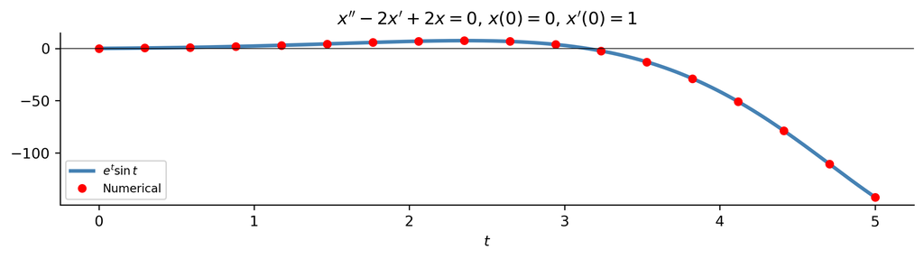

Figure 1

# Piecewise Continuous Forcing

## The Heaviside Approach

Why do we care? Methods from Chapter 2 fail for PWC forcing because we’d need to solve on each sub-interval and match solutions at every junction.

The Laplace method handles everything in **one calculation**.

**Example 3.18 (Logan)** — non-constant piecewise pieces:
$$f(t) = \begin{cases}t & 0<t<1 \\ 2 & 1\leq t\leq 3 \\ 0 & t>3\end{cases}
= t + (2-t)H(t-1) - 2H(t-3)$$

For $\mathscr{L}[tH(t-1)]$: use $\mathscr{L}[f(t)H(t-a)] = e^{-as}\mathscr{L}[f(t+a)]$ with $f(t)=t$:
$$\mathscr{L}[tH(t-1)] = e^{-s}\mathscr{L}[t+1] = e^{-s}\!\left(\frac{1}{s^2}+\frac{1}{s}\right)$$

$$F(s) = \frac{1}{s^2}+\frac{e^{-s}}{s}-\frac{e^{-s}}{s^2}-\frac{2e^{-3s}}{s}$$

## Example 3.19 — Oscillator, Half-Sine Forcing

**Solve:** $x''+4x = \sin t - H(t-\pi)\sin t$, $x(0)=x'(0)=0$.

**Key step — transform $H(t-\pi)\sin t$:**
$$\mathscr{L}[H(t-\pi)\sin t] = e^{-\pi s}\mathscr{L}[\sin(t+\pi)] = e^{-\pi s}\mathscr{L}[-\sin t] = -\frac{e^{-\pi s}}{s^2+1}$$

**(s^2+4)X = $\dfrac{1+e^{-\pi s}}{s^2+1}$**; PF: $A=1/3$, $B=-1/3$:

$$\mathscr{L}^{-1}\!\left[\frac{1}{(s^2+1)(s^2+4)}\right] = \frac{1}{3}\sin t - \frac{1}{6}\sin 2t$$

Switching property for $e^{-\pi s}$ term; $\sin(t-\pi)=-\sin t$:

$$\boxed{x(t) = \tfrac{1}{3}\sin t - \tfrac{1}{6}\sin 2t + H(t-\pi)\!\left(-\tfrac{1}{3}\sin t - \tfrac{1}{6}\sin 2t\right)}$$

## Example 3.19 — Solution Plot

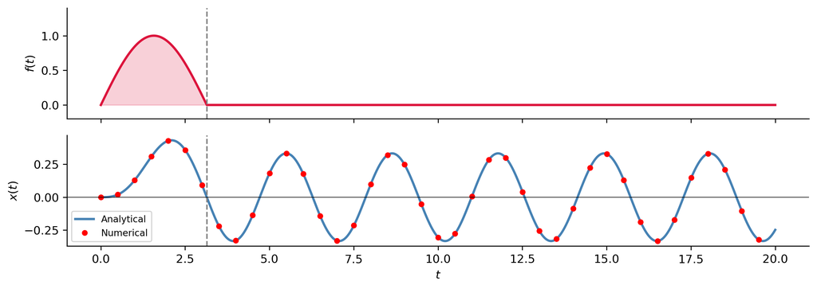

Figure 2

**Note**

After $t=\pi$ the oscillator runs **freely** at a modified amplitude — the forcing deposited energy that persists.

## Example 3.21 — RC Circuit, Square Pulse

**Solve:** $q'+3q = H(t-1)-H(t-2)$, $q(0)=0$.

$(s+3)Q = \dfrac{e^{-s}-e^{-2s}}{s}$; $\quad Q = \dfrac{e^{-s}}{s(s+3)} - \dfrac{e^{-2s}}{s(s+3)}$

PF: $\dfrac{1}{s(s+3)} = \dfrac{1/3}{s}-\dfrac{1/3}{s+3}$, so $\mathscr{L}^{-1}\!\left[\dfrac{1}{s(s+3)}\right] = \dfrac{1}{3}(1-e^{-3t})$.

Switching property for each term:

$$\boxed{q(t) = \tfrac{1}{3}(1-e^{-3(t-1)})H(t-1) - \tfrac{1}{3}(1-e^{-3(t-2)})H(t-2)}$$

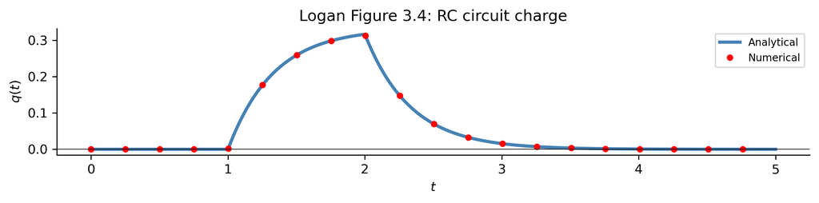

Figure 3

# Smoothing

## Remark 3.20 — PWC Input, Continuous Output

**Question:** if $f(t)$ is discontinuous, how smooth is $x(t)$?

**Answer (Remark 3.20):** $x(t)$ is always *more* regular than $f(t)$.

| ODE order | Input regularity | Output regularity |
| --- | --- | --- |
| 1st | PWC (jump) | Continuous |
| 2nd | PWC (jump) | Continuously differentiable |
| $n$th | PWC | $C^{n-1}$ |

**Example:** $x'' = H(t-3)$, $x(0)=x'(0)=0$.

$x'(t) = (t-3)H(t-3)$ — continuous, kink at $t=3$.

$x(t) = \frac{1}{2}(t-3)^2H(t-3)$ — smooth.

**Tip**

**Integration smooths.** Each integration adds one degree of regularity. The Laplace transform handles this automatically — you never need to patch solutions together at jump points.

# Summary

## Key Takeaways

- **Theorem 3.11** — $\mathscr{L}[x''] = s^2X-sx(0)-x'(0)$ — converts the ODE to algebra with ICs built in.
- **Three steps**: transform → solve for $X(s)$ → invert using table + PF.
- **Partial fractions**: distinct real poles → exponentials; repeated → $te^{at}$; complex → complete the square → damped sinusoids.
- **PWC forcing**: write $f(t)$ as Heaviside steps; transform using $\mathscr{L}[f(t)H(t-a)]=e^{-as}\mathscr{L}[f(t+a)]$; each $e^{-as}$ factor in $X(s)$ produces a time-delayed copy in $x(t)$.
- **Smoothing (Remark 3.20)**: a discontinuous input produces a continuous output — integration gains regularity, no case-by-case patching needed.

| Pole type | $X(s)$ form | $x(t)$ |
| --- | --- | --- |
| Distinct real | $\frac{A}{s-a}+\frac{B}{s-b}$ | $Ae^{at}+Be^{bt}$ |
| Repeated | $\frac{A}{s-a}+\frac{B}{(s-a)^2}$ | $Ae^{at}+Bte^{at}$ |
| Complex | $\frac{A(s-\alpha)+B\beta}{(s-\alpha)^2+\beta^2}$ | $e^{\alpha t}(A\cos\beta t+B\sin\beta t)$ |

## References

Logan, J David. 2015. *A First Course in Differential Equations, Third Edition*.